# Moment-generating function

## Moment-generating function: definition

**Moment-generating function** of r.v. $X$ is $$ M_X(t) = \mathbb{E}\left[e^{tX}\right] $$

It does not always exist. If it exists and is finite:

- It uniquely defines distribution of $X$
- $M_X(t) > 0, \forall t$ and $M_X(0) = 1$
- $M_{aX+b}(t) = e^{bt} M_X(at)$
- For all $k$ exists a finite moment of $X$ and is defined as $\mathbb{E}[X^k] = M^{(k)}_X(0)$ meaning $k$-th derivative

The purpose of MGF is to replace computation of expectation with differentiation.

## Example 1: Bernoulli MGF

Consider $X \sim Be(p)$. What is $M_X(t)$? Find expectation and variance using MGF.

## Solution 1

MGF: $$ M_X(t) = \mathbb{E}\left[e^{tX}\right] = e^{t \cdot 0} \cdot \mathbb{P}(X = 0) + e^{t \cdot 1} \cdot \mathbb{P}(X = 1) = q + pe^t $$

First and second derivatives are $pe^t$, so $$ \mathbb{E}X = M'_X(0) = pe^0 = p = M''_X(0) = \mathbb{E}\left[X^2\right] $$ $$ \mathbb{V}\text{ar}(X) = M''_X(0) - \left(M'_X(0)\right)^2 = p - p^2 = p(1-p) $$

## Example 2: Poisson MGF

Consider $X \sim Pois(\lambda)$. What is $M_X(t)$? Find expectation and variance using MGF.

## Solution 2

MGF: $$ M_X(t) = \mathbb{E}\left[e^{tX}\right] = \sum\limits_{k=-\infty}^\infty e^{tk} \frac{\lambda^k}{k!} e^{-\lambda} = e^{-\lambda} \sum\limits_{k=-\infty}^\infty \frac{1}{k!} \left( \lambda e^{t}\right)^k = \exp \left( \lambda \left( e^t - 1 \right) \right) $$

First derivative: $$ M'_X(t) = \lambda e^t \exp \left( \lambda \left( e^t - 1 \right) \right) $$

Expectation $M'_X(0) = \lambda$. Second derivative: $$ M''_X(0) = \lambda e^t \exp \left( \lambda \left( e^t - 1 \right) \right) + \lambda e^t \exp \lambda e^t \left( \lambda \left( e^t - 1 \right) \right) $$

Second moment $M''_X(0) = \lambda + \lambda^2$. Variance $\mathbb{V}\text{ar}(X) = \lambda + \lambda^2 - \lambda^2 = \lambda$.

## Example 3: Gaussian MGF

Consider $X \sim \mathcal{N}(\mu, \sigma^2)$. What is $M_X(t)$? Find expectation and variance using MGF.

## Solution 3

First let's find for $Y \sim \mathcal{N}(0, 1)$, then apply properties. $$ \begin{aligned} M_Y(t) & = \mathbb{E}\left[e^{tY}\right] = \frac{1}{\sqrt{2\pi}} \int\limits_{-\infty}^\infty e^{tx} e^{-x^2 / 2} dx = \frac{1}{\sqrt{2\pi}} \int\limits_{-\infty}^\infty \exp\left( -\frac{x^2 - 2tx}{2}\right) dx = \\ & = \frac{1}{\sqrt{2\pi}} \int\limits_{-\infty}^\infty \exp\left( -\frac{(x - t)^2 - t^2}{2}\right) dx = \\ & = \exp\left( \frac{t^2}{2} \right) \frac{1}{\sqrt{2\pi}} \int\limits_{-\infty}^\infty \exp\left( -\frac{(x - t)^2}{2}\right) dx = \exp\left( \frac{t^2}{2} \right) \end{aligned} $$

## Solution 3 (continued)

From properties, $M_X(t) = e^{\mu t} M_Y(\sigma t) = \exp \left( \mu t + \frac{t^2 \sigma^2}{2} \right)$. First derivative: $$ M'_X(t) = \left( \mu + t \sigma^2 \right) \exp \left( \mu t + \frac{t^2 \sigma^2}{2} \right) $$

Second derivative: $$ M''_X(t) = \sigma^2 \exp \left( \mu t + \frac{t^2 \sigma^2}{2} \right) + \left( \mu + t \sigma^2 \right)^2 \exp \left( \mu t + \frac{t^2 \sigma^2}{2} \right) $$

Expectation: $M'_X(0) = \mu$, variance $M''_X(0) - \left( M'_X(0) \right)^2 = \sigma^2$.

# Random vector

## Random vector: definition

Consider probability space $(S, \mathbb{P})$. Then, a **random vector** is a function $$ \mathbf{X}: \Omega \to \mathbb{R}^n, $$ where $\mathbf{X} = (X_1, \ldots, X_n)^\top$. Every component $X_i$ of the vector is a random variable. The converse is also true: for any r.v.s $X_1, \ldots, X_n$ a vector $(X_1, \ldots, X_n)^\top$ is a random vector.

## Random vector: distribution

The distribution of a random vector $\mathbf{X} = (X_1, \ldots, X_n)^\top$ can be described via **multivariate (joint) cumulative distribution function**: $$ F_{\mathbf{X}}(\mathbf{x}) = \mathbb{P}(X_1 < x_1, X_2 < x_2, \ldots, X_n < x_n) $$

Properties of multivariate CDF:

- $\lim_{x_i \to -\infty} F_{\mathbf{X}}(\mathbf{x}) = 0$ but $\lim_{x_1, \ldots, x_n \to \infty} F_{\mathbf{X}}(\mathbf{x}) = 1$
- $\lim_{x_i \to \infty} F_{\mathbf{X}}(\mathbf{x}) = $ the function $F$ of everything except $x_i$
- $F_{\mathbf{X}}(\mathbf{x})$ is non-decreasing and left-continuous in every component
- Supermodulatiry: $F_{\mathbf{X}}(x_1, \ldots, x_i, \ldots, x_n) - F_{\mathbf{X}}(x_1, \ldots, x_i - \varepsilon, \ldots, x_n) \geqslant 0$

## Random vector: distribution

If $X$ has continuous distribution, then exists **multivariate (joint) probability density function**, i.e. non-negative function $f_{\mathbf{X}}(\cdot)$ such that $$ \mathbb{P}(\mathbf{X} \in B) = \int_B f_{\mathbf{X}}(x_1, \ldots, x_n) dx_1 \ldots dx_n $$

PDF can also be found from CDF: $$ f_{\mathbf{X}}(\mathbf{x}) = \frac{\partial^n F_{\mathbf{X}}(\mathbf{x})}{\partial x_1 \ldots \partial x_n} $$

## Random vector: independence

If all r.v.s $X_i$ are independent, then $$ \begin{cases} F_{\mathbf{X}}(\mathbf{x}) & = \prod\limits_{i=1}^n F_{X_i}(x_i), \\ f_{\mathbf{X}}(\mathbf{x}) & = \prod\limits_{i=1}^n f_{X_i}(x_i) \end{cases} $$

## Random vector: moments

**Mathematical expectation** of a random vector is a vector of mathematical expectations of its components: $$ \mathbb{E}\left[\mathbf{X}\right] = (\mathbb{E}X_1, \ldots, \mathbb{E}X_n)^\top $$

Second moments of a random vector are described with **covariance matrix** $\mathbb{V}\text{ar}(\mathbf{X}) = \Sigma$, where $$ \Sigma_{ij} = \operatorname{cov}(X_i, X_j) $$

$$ \Sigma_{ij} = \operatorname{cov}(X_i, X_j) = \mathbb{E} \left[ (X_i - \mathbb{E} X_i) (X_j - \mathbb{E} X_j) \right] $$

In particular, the diagonal elements are variances: $\Sigma_{ii} = \mathbb{V}\text{ar}(X_i)$.

## Random vector: LOTUS

Let $g(\cdot): \mathbb{R}^2 \to \mathbb{R}$, then $$ \mathbb{E}\left[g(X, Y)\right] = \sum\limits_m \sum\limits_n g(m, n) \mathbb{P}(X = m, Y = n) $$ if $X, Y$ are continuous r.v.s; if they are continuous: $$ \mathbb{E}\left[g(X, Y)\right] = \int\int g(x, y) f_{X, Y}(x, y) {\rm d} x {\rm d} y $$

## Covariance

**Covariance** of two random variables $X$ and $Y$ is defined as $$ \operatorname{cov}\left(X, Y\right) = \mathbb{E}\left[\left(X - \mathbb{E}\left[X\right]\right)\left(Y - \mathbb{E}\left[Y\right]\right)\right] = \mathbb{E}\left[XY\right] - \mathbb{E}\left[X\right]\mathbb{E}\left[Y\right] $$

Properties of covariance:

- $\operatorname{cov}\left(X, X\right) = \mathbb{V}\text{ar}\left(X\right)$
- $\operatorname{cov}\left(X, Y\right) = \operatorname{cov}\left(Y, X\right)$
- $\operatorname{cov}\left(X, c\right) = 0, \; \forall c$
- $\operatorname{cov}\left(aX, Y\right) = a \operatorname{cov}\left(X, Y\right)$
- $\operatorname{cov}\left(X + Y, Z\right) = \operatorname{cov}\left(X, Z\right) + \operatorname{cov}\left(Y, Z\right)$
- $\operatorname{cov}\left(X + Y, Z + W\right) = \operatorname{cov}\left(X, Z\right) + \operatorname{cov}\left(X, W\right) + \operatorname{cov}\left(Y, Z\right) + \operatorname{cov}\left(Y, W\right)$
- $\mathbb{V}\text{ar}\left(X + Y\right) = \mathbb{V}\text{ar}\left(X\right) + \mathbb{V}\text{ar}\left(Y\right) + 2 \operatorname{cov}\left(X, Y\right)$

## Correlation

If $X \perp Y$, $\operatorname{cov}\left(X, Y\right) = 0$. The converse is not true. Regardless, covariance is often used to measure the dependency between random variables. It is not handy to use, so instead a **correlation coefficient** is proposed: $$ r_{XY} = \frac{\operatorname{cov}\left(X, Y\right)}{\sqrt{\mathbb{V}\text{ar}\left(X\right)\mathbb{V}\text{ar}\left(Y\right)}} $$

Note that $-1 \leqslant r_{XY} \leqslant 1$.

```python
import numpy as np
import scipy.stats as sts

import IPython.display as dp
import matplotlib.pyplot as plt
import seaborn as sns

dp.set_matplotlib_formats("retina")
sns.set(style="whitegrid", font_scale=1.5)
sns.despine()

%matplotlib inline
```

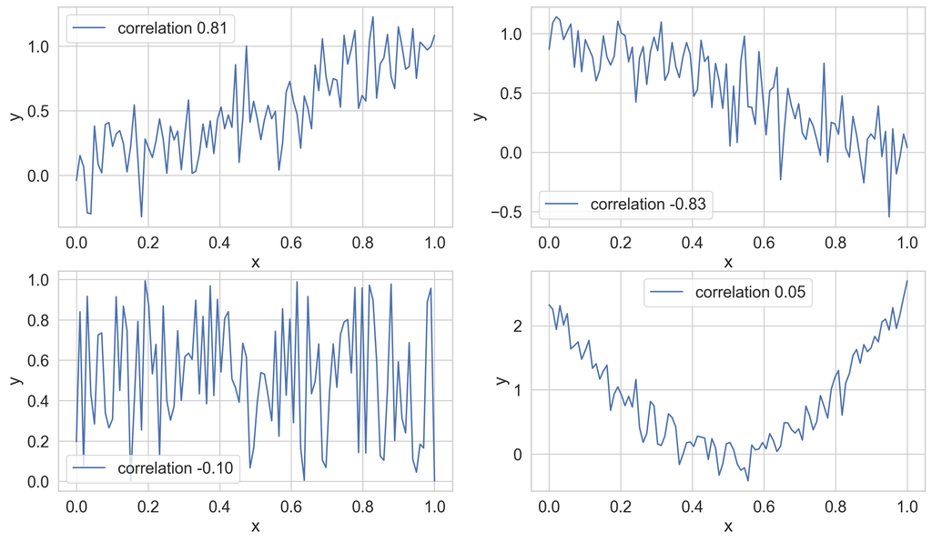

```python
n = 100
s = 1/5
x = np.linspace(0, 1, n)
y1 = x + sts.norm(scale=s).rvs(n)
y2 = 1 - x + sts.norm(scale=s).rvs(n)
y3 = sts.uniform().rvs(n)
y4 = 10 * (x - 0.5) ** 2 + sts.norm(scale=s).rvs(n)

fig, axes = plt.subplots(2,2,figsize=(16,9))
for ax, y in zip(axes.flatten(), [y1, y2, y3, y4]):
    ax.plot(x, y, label=f"correlation {np.corrcoef(x, y)[0, 1]:.2f}")
    ax.set_xlabel("x")
    ax.set_ylabel("y")
    ax.legend();
```

## Random vector: covariance matrix

Matrix notation for covariance matrix is $\mathbb{V}\text{ar}(\mathbf{X}) = \mathbb{E}\left[(\mathbf{X} - \mathbb{E}[\mathbf{X}]) (\mathbf{X} - \mathbb{E}[\mathbf{X}])^\top\right]$.

Properties of convariance matrix:

- Symmetry $\Sigma^\top = \Sigma$
- Non-negative semi-definite: $a^\top \Sigma a \geqslant 0, \forall a$

## Random vector: marginal and conditional distributions

**Marginal distribution** is the distribution of a subset of a random vector. For example, consider r.v. $\mathbf{X} \in \mathbb{R}^n$ and let's view it as two vectors, $\mathbf{Y} \in \mathbb{R}^k$ and $\mathbf{Z} \in \mathbb{R}^{n-k}$, stacked: $\mathbf{X} = (\mathbf{Y}^\top, \mathbf{Z}^\top)^\top$. The marginal distribution of $\mathbf{Z}$ then will be: $$ f_{\mathbf{Z}}(\mathbf{z}) = \int_{\mathbb{R}^k} f_{\mathbf{X}}(\mathbf{y}, \mathbf{z}) d \mathbf{y} $$

In words, we take distribution of $\mathbf{X}$ and **integrate out** everything not realted to $\mathbf{Z}$.

We may also define **conditional distribution**: $$ f_{\mathbf{Y}|\mathbf{Z}=\mathbf{z}}(\mathbf{y}) = \frac{f_{\mathbf{X}}(\mathbf{y}, \mathbf{z})}{f_{\mathbf{Z}}(\mathbf{z})} $$

## Example 4: joint, marginal and conditional distributions for discrete case

Let $X$ be the indicator of the sampled individual being a current smoker, and let $Y$ be the indicator of his developing lung cancer at some point in his life. Suppose the joint PMF is as follows:

|  | $Y=1$ | $Y=0$ |
| --- | --- | --- |
| $X=1$ | $\frac{5}{100}$ | $\frac{20}{100}$ |
| $X=0$ | $\frac{3}{100}$ | $\frac{72}{100}$ |

Find the marginal and consitional distributions.

## Solution 4

|  | $Y=1$ | $Y=0$ |
| --- | --- | --- |
| $X=1$ | $\frac{5}{100}$ | $\frac{20}{100}$ |
| $X=0$ | $\frac{3}{100}$ | $\frac{72}{100}$ |

$$ \mathbb{P}(X = x) = \sum_y \mathbb{P}(X = x, Y = y) $$

|  | $Y=1$ | $Y=0$ | $\text{Sum}$ |
| --- | --- | --- | --- |
| $X=1$ | $\frac{5}{100}$ | $\frac{20}{100}$ | $\frac{25}{100}$ |
| $X=0$ | $\frac{3}{100}$ | $\frac{72}{100}$ | $\frac{75}{100}$ |
| $\text{Sum}$ | $\frac{8}{100}$ | $\frac{92}{100}$ | $\frac{100}{100}$ |

## Solution 4

|  | $Y=1$ | $Y=0$ |
| --- | --- | --- |
| $X=1$ | $\frac{5}{100}$ | $\frac{20}{100}$ |
| $X=0$ | $\frac{3}{100}$ | $\frac{72}{100}$ |

$$ \mathbb{P}(Y = y | X = x) = \frac{\mathbb{P}(X = x, Y = y)}{\mathbb{P}(X = x)} $$

Example: if the person is a smoker ($X = 1$), then $\mathbb{P}(Y = 1 | X = 1) = \frac{\mathbb{P}(X = 1, Y = 1)}{\mathbb{P}(X = 1)} = \frac{5/100}{25/100} = 0.2$.

## Example 5 (unit disc)

Consider a random point on unit disc with random coordinates $(X, Y)$. What is the joint, marginal and conditional PDF for the coordinates?

## Solution 5

The joint is $$ f_{X, Y}(x, y) = \begin{cases} \frac1\pi, \text{ if } x^2 + y^2 \leqslant 1, \\ 0, \text{ else} \end{cases} $$

The marginal for $X$ is: $$ f_X(x) = \int\limits_{-\infty}^\infty f_{X, Y}(x, y) dy = \int\limits_{-\sqrt{1 - x^2}}^{\sqrt{1-x^2}} \frac{1}{\pi} dy = \frac{2}{\pi} \sqrt{1 - x^2} $$

The conditional for $Y$ is: $$ f_{Y|X=x}(x) = \frac{f_{X, Y}(x, y)}{f_{X}(x)} = \frac{\frac{1}{\pi}}{\frac{2}{\pi}\sqrt{1 - x^2}} = \frac{1}{2\sqrt{1 - x^2}} $$